# Visualizing Ford GoBike System Data (Bay Wheels)

# Introduction

> Bay Wheels is a regional public bicycle sharing system in the San Francisco Bay Area, California operated by Motivate in a partnership with the Metropolitan Transportation Commission and the Bay Area Air Quality Management District. Bay Wheels is the first regional and large-scale bicycle sharing system deployed in California and on the West Coast of the United States. It was established as Bay Area Bike Share in August 2013. As of January 2018, the Bay Wheels system had over 2,600 bicycles in 262 stations across San Francisco, East Bay and San Jose. On June 28, 2017, the system officially re-launched as Ford GoBike in a partnership with Ford Motor Company. After Motivate's acquisition by Lyft, the system was subsequently renamed to Bay Wheels in June 2019. The system is expected to expand to 7,000 bicycles around 540 stations in San Francisco, Oakland, Berkeley, Emeryville, and San Jose.

```python
import numpy as np
import pandas as pd
import matplotlib.pyplot as plt
import seaborn as sb
import geopy.distance

%matplotlib inline
```

## Wrangling Data

```python
df = pd.read_csv('202003-baywheels-tripdata.csv')
df = df.append(pd.read_csv('202002-baywheels-tripdata.csv'))
df = df.append(pd.read_csv('202001-baywheels-tripdata.csv'))
```

```python
df.head(3)
```

|  | duration_sec | start_time | end_time | start_station_id | start_station_name | start_station_latitude | start_station_longitude | end_station_id | end_station_name | end_station_latitude | end_station_longitude | bike_id | user_type | rental_access_method |
| --- | --- | --- | --- | --- | --- | --- | --- | --- | --- | --- | --- | --- | --- | --- |
| 0 | 35187 | 2020-03-31 20:42:10.0790 | 2020-04-01 06:28:37.8440 | 462.0 | Cruise Terminal at Pier 27 | 37.804648 | -122.402087 | 24.0 | Spear St at Folsom St | 37.789677 | -122.390428 | 10982 | Customer | NaN |
| 1 | 14568 | 2020-03-31 22:45:25.5010 | 2020-04-01 02:48:13.7730 | 42.0 | San Francisco City Hall (Polk St at Grove St) | 37.778650 | -122.418230 | 370.0 | Jones St at Post St | 37.787327 | -122.413278 | 12617 | Customer | NaN |
| 2 | 35990 | 2020-03-31 15:08:22.3310 | 2020-04-01 01:08:12.9900 | 391.0 | 1st St at Younger Ave | 37.355030 | -121.904436 | 397.0 | Gish Rd at 1st St | 37.361867 | -121.909315 | 12812 | Customer | NaN |

```python
df.info()
```

```
<class 'pandas.core.frame.DataFrame'>
Int64Index: 905007 entries, 0 to 295853
Data columns (total 14 columns):
 #   Column                   Non-Null Count   Dtype
---  ------                   --------------   -----
 0   duration_sec             905007 non-null  int64
 1   start_time               905007 non-null  object
 2   end_time                 905007 non-null  object
 3   start_station_id         418705 non-null  float64
 4   start_station_name       419938 non-null  object
 5   start_station_latitude   905007 non-null  float64
 6   start_station_longitude  905007 non-null  float64
 7   end_station_id           419225 non-null  float64
 8   end_station_name         420499 non-null  object
 9   end_station_latitude     905007 non-null  float64
 10  end_station_longitude    905007 non-null  float64
 11  bike_id                  905007 non-null  int64
 12  user_type                905007 non-null  object
 13  rental_access_method     617858 non-null  object
dtypes: float64(6), int64(2), object(6)
memory usage: 103.6+ MB
```

```python
df.describe()
```

|  | duration_sec | start_station_id | start_station_latitude | start_station_longitude | end_station_id | end_station_latitude | end_station_longitude | bike_id |
| --- | --- | --- | --- | --- | --- | --- | --- | --- |
| count | 905007.000000 | 418705.000000 | 905007.000000 | 905007.000000 | 419225.000000 | 905007.000000 | 905007.000000 | 905007.000000 |
| mean | 806.783430 | 175.490438 | 37.747956 | -122.356863 | 168.499295 | 37.747504 | -122.354743 | 345257.165427 |
| std | 1651.803494 | 146.361852 | 0.229245 | 0.646076 | 145.618964 | 0.270214 | 0.795225 | 305503.123238 |
| min | 60.000000 | 3.000000 | 0.000000 | -122.514230 | 3.000000 | 0.000000 | -122.575763 | 12.000000 |
| 25% | 370.000000 | 56.000000 | 37.765281 | -122.420664 | 44.000000 | 37.765464 | -122.419957 | 12114.000000 |
| 50% | 595.000000 | 123.000000 | 37.776972 | -122.404635 | 116.000000 | 37.777062 | -122.403681 | 326439.000000 |
| 75% | 932.000000 | 275.000000 | 37.789914 | -122.392741 | 265.000000 | 37.790229 | -122.392741 | 557460.000000 |
| max | 811077.000000 | 521.000000 | 37.880222 | 0.000000 | 521.000000 | 37.995942 | 0.000000 | 999960.000000 |

```python
df.isnull().sum()
```

```
duration_sec                    0
start_time                      0
end_time                        0
start_station_id           486302
start_station_name         485069
start_station_latitude          0
start_station_longitude         0
end_station_id             485782
end_station_name           484508
end_station_latitude            0
end_station_longitude           0
bike_id                         0
user_type                       0
rental_access_method       287149
dtype: int64
```

```python
df.duplicated().sum()
```

```
7512
```

```python
df['user_type'].unique(), df['bike_id'].nunique(), df['rental_access_method'].unique()
```

```
(array(['Customer', 'Subscriber'], dtype=object),
 10233,
 array([nan, 'app', 'clipper'], dtype=object))
```

```python
df_clean = df.copy()
```

```python
df_clean.drop_duplicates(inplace=True)
```

```python
df_clean.drop(['start_station_id', 'start_station_name', 'end_station_id', 'end_station_name'], axis= 1 , inplace= True)
```

```python
df_clean['start_time'] = pd.to_datetime(df_clean['start_time'])
df_clean['end_time'] = pd.to_datetime(df_clean['end_time'])
```

```python
df_clean.info()
```

```
<class 'pandas.core.frame.DataFrame'>
Int64Index: 897495 entries, 0 to 295853
Data columns (total 10 columns):
 #   Column                   Non-Null Count   Dtype
---  ------                   --------------   -----
 0   duration_sec             897495 non-null  int64
 1   start_time               897495 non-null  datetime64[ns]
 2   end_time                 897495 non-null  datetime64[ns]
 3   start_station_latitude   897495 non-null  float64
 4   start_station_longitude  897495 non-null  float64
 5   end_station_latitude     897495 non-null  float64
 6   end_station_longitude    897495 non-null  float64
 7   bike_id                  897495 non-null  int64
 8   user_type                897495 non-null  object
 9   rental_access_method     610346 non-null  object
dtypes: datetime64[ns](2), float64(4), int64(2), object(2)
memory usage: 75.3+ MB
```

```python
df_clean['day_start'] = df_clean.start_time.dt.day_name()
df_clean['day_end'] = df_clean.end_time.dt.day_name()
```

```python
df_clean['month_start'] = df_clean.start_time.dt.month
df_clean['month_end'] = df_clean.end_time.dt.month
```

```python
df_clean['hour_start'] = df_clean.start_time.dt.hour
df_clean['hour_end'] = df_clean.end_time.dt.hour
```

```python
df_clean['duration_min'] = df_clean['duration_sec']/60
df_clean['duration_min'] = df_clean['duration_min'].round(1)
```

```python
df_clean.head(1)
```

|  | duration_sec | start_time | end_time | start_station_latitude | start_station_longitude | end_station_latitude | end_station_longitude | bike_id | user_type | rental_access_method | day_start | day_end | month_start | month_end | hour_start | hour_end | duration_min |
| --- | --- | --- | --- | --- | --- | --- | --- | --- | --- | --- | --- | --- | --- | --- | --- | --- | --- |
| 0 | 35187 | 2020-03-31 20:42:10.079 | 2020-04-01 06:28:37.844 | 37.804648 | -122.402087 | 37.789677 | -122.390428 | 10982 | Customer | NaN | Tuesday | Wednesday | 3 | 4 | 20 | 6 | 586.4 |

```python
df_clean.drop(df_clean[df_clean['duration_min'] > 1500].index, inplace = True)
```

```python
df_clean['duration_min'].describe()
```

```
count    897492.000000
mean         13.420667
std          23.626877
min           1.000000
25%           6.200000
50%           9.900000
75%          15.500000
max        1438.600000
Name: duration_min, dtype: float64
```

```python
df_clean.drop(df_clean[df_clean['start_time'] >= '2020-04-01'].index, inplace = True)
```

```python
df_clean.info()
```

```
<class 'pandas.core.frame.DataFrame'>
Int64Index: 892320 entries, 0 to 295853
Data columns (total 17 columns):
 #   Column                   Non-Null Count   Dtype
---  ------                   --------------   -----
 0   duration_sec             892320 non-null  int64
 1   start_time               892320 non-null  datetime64[ns]
 2   end_time                 892320 non-null  datetime64[ns]
 3   start_station_latitude   892320 non-null  float64
 4   start_station_longitude  892320 non-null  float64
 5   end_station_latitude     892320 non-null  float64
 6   end_station_longitude    892320 non-null  float64
 7   bike_id                  892320 non-null  int64
 8   user_type                892320 non-null  object
 9   rental_access_method     606976 non-null  object
 10  day_start                892320 non-null  object
 11  day_end                  892320 non-null  object
 12  month_start              892320 non-null  int64
 13  month_end                892320 non-null  int64
 14  hour_start               892320 non-null  int64
 15  hour_end                 892320 non-null  int64
 16  duration_min             892320 non-null  float64
dtypes: datetime64[ns](2), float64(5), int64(6), object(4)
memory usage: 122.5+ MB
```

```python
df_clean['distance_km'] = df_clean.apply(lambda x: geopy.distance.geodesic((x[3], x[4]), (x[5], x[6])).km, axis = 1)
```

```python
df_clean['distance_km'] = df_clean['distance_km'].round(2)
```

```python
df_clean['distance_km'].describe()
```

```
count    892320.000000
mean          2.701771
std         104.986637
min           0.000000
25%           0.910000
50%           1.540000
75%           2.490000
max       12809.890000
Name: distance_km, dtype: float64
```

```python
df_clean.drop(df_clean[df_clean['distance_km'] > 20].index, inplace = True)
```

```python
df_clean.head(2)
```

|  | duration_sec | start_time | end_time | start_station_latitude | start_station_longitude | end_station_latitude | end_station_longitude | bike_id | user_type | rental_access_method | day_start | day_end | month_start | month_end | hour_start | hour_end | duration_min | distance_km |
| --- | --- | --- | --- | --- | --- | --- | --- | --- | --- | --- | --- | --- | --- | --- | --- | --- | --- | --- |
| 0 | 35187 | 2020-03-31 20:42:10.079 | 2020-04-01 06:28:37.844 | 37.804648 | -122.402087 | 37.789677 | -122.390428 | 10982 | Customer | NaN | Tuesday | Wednesday | 3 | 4 | 20 | 6 | 586.4 | 1.95 |
| 1 | 14568 | 2020-03-31 22:45:25.501 | 2020-04-01 02:48:13.773 | 37.778650 | -122.418230 | 37.787327 | -122.413278 | 12617 | Customer | NaN | Tuesday | Wednesday | 3 | 4 | 22 | 2 | 242.8 | 1.06 |

```python
df_clean.to_csv('df_ford_clean.csv', index= False, encoding='utf-8')
```

## Exploration Data

### Univariate Exploration

```python
df_clean.groupby('bike_id').sum().duration_min.nlargest(5).to_frame(), df_clean.groupby('bike_id').sum().duration_min.nsmallest(5).to_frame()
```

```
(         duration_min
 bike_id
 892636         5976.1
 954422         5622.2
 870495         5552.7
 260006         5528.7
 379167         5423.6,
          duration_min
 bike_id
 737676            1.0
 175494            1.2
 895862            1.2
 3020              1.3
 249290            1.4)
```

**Most popular bike_id.**

```python
df_clean['day_start'].describe()
```

```
count        892138
unique            7
top       Wednesday
freq         146652
Name: day_start, dtype: object
```

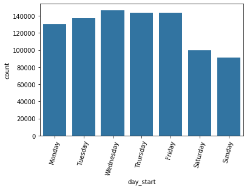

```python
base_color = sb.color_palette()[0]
day = ['Monday', 'Tuesday', 'Wednesday', 'Thursday', 'Friday', 'Saturday', 'Sunday']
sb.countplot(data = df_clean, x = 'day_start', color = base_color, order = day)
plt.xticks(rotation = 75);
```

**Renting bikes during a weekday are higher than during weekend. The most popular day is Wednesday.**

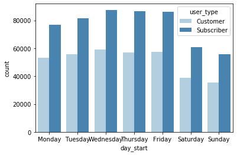

```python
#ax = plt.subplot(6, 10, 5);
sb.countplot(data = df_clean, x = 'day_start', hue = 'user_type',order = day, palette = 'Blues');
```

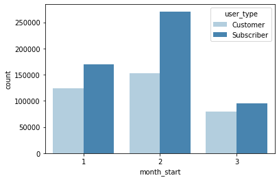

```python
sb.countplot(data = df_clean, x = 'month_start', hue = 'user_type', palette = 'Blues');
```

**We have more "subscribers" than "customers" but both of tham are pretty same if we consider differences between weekday and weekend.**

```python
df_clean['duration_min'].describe()
```

```
count    892138.000000
mean         13.401160
std          23.340304
min           1.000000
25%           6.200000
50%           9.900000
75%          15.500000
max        1438.600000
Name: duration_min, dtype: float64
```

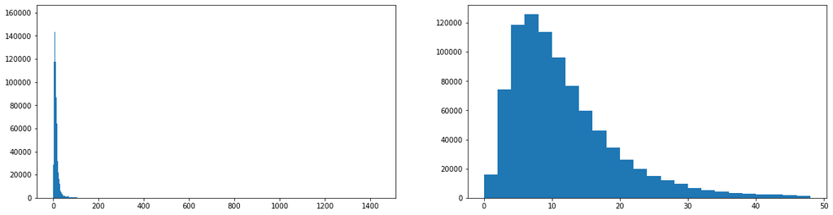

```python
plt.figure(figsize = [20, 5])

#full data
plt.subplot(1, 2, 1)
bin_edges = np.arange(0, df_clean['duration_min'].max()+2.5, 2.5)
plt.hist(data = df_clean, x = 'duration_min', bins = bin_edges)

plt.subplot(1, 2, 2)
bin_edges = np.arange(0, 50, 2)
plt.hist(data = df_clean, x = 'duration_min', bins = bin_edges);
```

**We have only few customers which has rented bike for more than 100 minuts. So we added one more graph where we can see that more people rent bike from 2 to 20 minutes.**

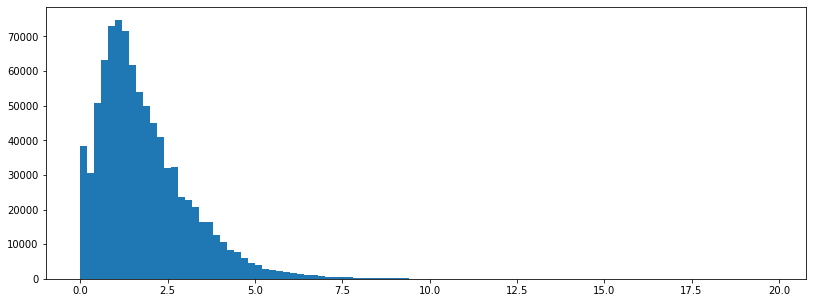

```python
plt.figure(figsize = [30, 5])
plt.subplot(1, 2, 1)
bin_edges = np.arange(0, 20, 0.2)
plt.hist(data = df_clean, x = 'distance_km', bins = bin_edges);
```

**This graph shows distance from start point to end point. We calculated the shortes way between two points with geopy library. Graphs show us, that people are using bikes only in small circle, the most frequent is from 0 to 3 kilometres.**

### Bivariate Exploration

```python
df_clean.head(1)
```

|  | duration_sec | start_time | end_time | start_station_latitude | start_station_longitude | end_station_latitude | end_station_longitude | bike_id | user_type | rental_access_method | day_start | day_end | month_start | month_end | hour_start | hour_end | duration_min | distance_km |
| --- | --- | --- | --- | --- | --- | --- | --- | --- | --- | --- | --- | --- | --- | --- | --- | --- | --- | --- |
| 0 | 35187 | 2020-03-31 20:42:10.079 | 2020-04-01 06:28:37.844 | 37.804648 | -122.402087 | 37.789677 | -122.390428 | 10982 | Customer | NaN | Tuesday | Wednesday | 3 | 4 | 20 | 6 | 586.4 | 1.95 |

```python
customer = df_clean.query('user_type == "Customer"')['bike_id'].count()
subscriber = df_clean.query('user_type == "Subscriber"')['bike_id'].count()
```

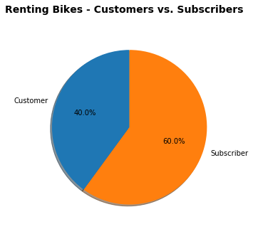

```python
plt.figure(figsize = [8, 5])
plt.suptitle('Renting Bikes - Customers vs. Subscribers', fontsize=14, fontweight='bold')
labels = ['Customer', 'Subscriber']
size = [customer, subscriber]
plt.pie(size, labels = labels, autopct='%1.1f%%', shadow=True, startangle=90);
```

**Distribution between Customer and Subscriber**

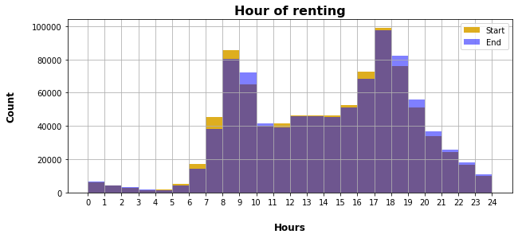

```python
bin_edges = np.arange(0, 25)
ax = df_clean['hour_start'].hist(alpha=0.9, bins = bin_edges, figsize=(10,4),label = 'Start', color='#DBA506')
ay = df_clean['hour_end'].hist(alpha=0.5, bins = bin_edges,  figsize=(10,4), label = 'End', color='blue')
ax.set_title('Hour of renting', weight='bold', size=16)
ax.set_xlabel('Hours', labelpad=20, weight='bold', size=12)
ax.set_ylabel('Count', labelpad=20, weight='bold', size=12)
plt.xticks(np.arange(0, 25, 1))
plt.legend();
```

**Graph shows time when people start renting bike and end of their ride. Start/End of renting bikes is the most at the morning before work and also after work from 4 pm.**

```python
def box_func(colname):
    plt.figure(figsize = [10, 5])
    base_color = sb.color_palette()[0]
    sb.boxplot(data = df_clean, x = 'day_start', y = colname, color = base_color, order = day);
```

```python
def violin_func(colname):
    plt.figure(figsize = [10, 5])
    base_color = sb.color_palette()[0]
    sb.violinplot(data = df_clean, x = 'day_start', y = colname, color = base_color, order = day, inner = None);
```

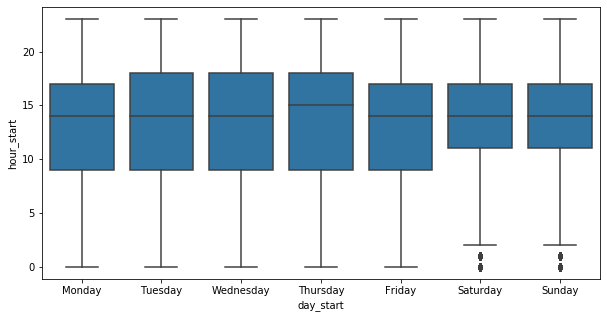

```python
box_func('hour_start')
```

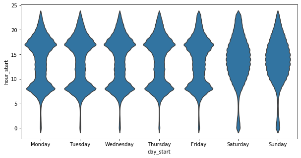

```python
violin_func('hour_start')
```

**From violin plot is really nice view of how people are using bikes before work and after. On the other hand, during a weekend are most favorite hours between 12-17 hour o'clock.**

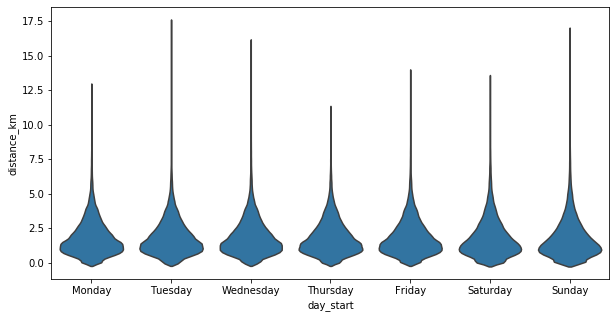

```python
violin_func('distance_km')
```

**Low distance is preferred.**

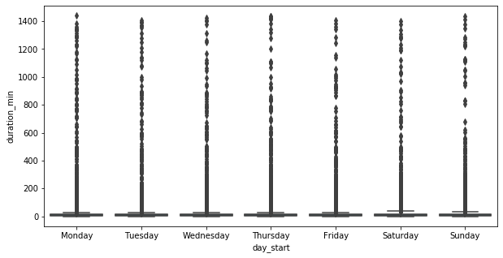

```python
box_func('duration_min')
```

**BoxPlot for duration need change if we wanna use it.**

[figure not shown]

```python
plt.figure(figsize = [10, 5])
plt.scatter(data = df_clean, x = 'duration_min', y = 'distance_km', alpha = 1/10)
plt.title('How far and How long', weight = 'bold')
plt.xlabel('Duration in minutes')
plt.ylabel('Distance in km')
plt.xscale('log');
plt.xticks([1, 5, 10, 20, 50, 100, 500, 1500], [1, 5, 10, 20, 50, 100, 500, 1500]);
```

### Multivariate Exploration

```python
var = ['start_station_latitude','start_station_longitude','end_station_latitude','end_station_longitude','bike_id','user_type', 'duration_min','distance_km','hour_start','hour_end']
```

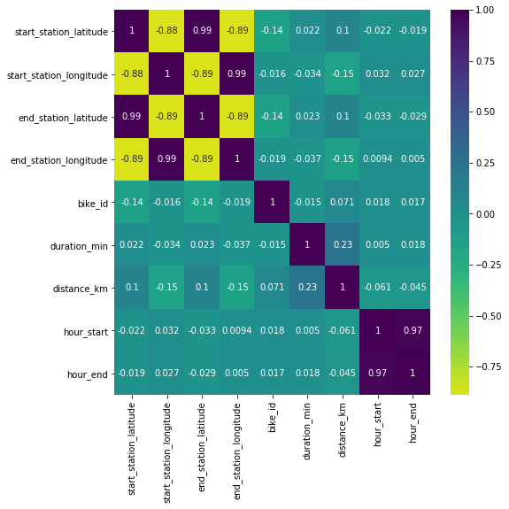

```python
plt.figure(figsize = [8, 8])
sb.heatmap(df_clean[var].corr(), annot = True, cmap = 'viridis_r', center = 0);
```

When we look on heat map, we can see strong correlations between latitude and logitude but the most significant is between start_station_latitude end end_station_latitude and same for start and end longitude. It looks like people get bike on the same position as they start.  
Second strong correlation is between hour_start and hour_end. Reason can by the low duration renting time.  
*

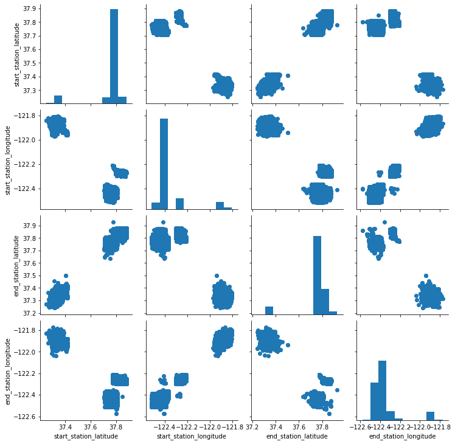

```python
g = sb.PairGrid(data = df_clean, vars = ['start_station_latitude', 'start_station_longitude', 'end_station_latitude', 'end_station_longitude'])
g.map_diag(plt.hist)
g.map_offdiag(plt.scatter);
```

**Check if there is correletion between start station and end station.**

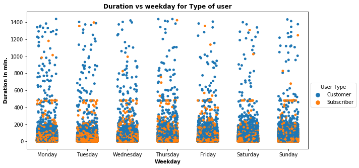

```python
plt.figure(figsize = [10, 5])
ax = sb.stripplot(data = df_clean, x = 'day_start', y = 'duration_min', hue = 'user_type', jitter = 0.25, order = day)
ax.legend(loc = 8, ncol = 3, framealpha = 1, title = 'user_type')
plt.xlabel('Weekday', weight = 'bold')
plt.ylabel('Duration in min.', weight = 'bold')
plt.title('Duration vs weekday for Type of user', weight = 'bold')
plt.legend(bbox_to_anchor = (1, 0.5),title = 'User Type');
```

[figure not shown]

```python
plt.subplots(figsize=(15, 7))
df_heat_map = df_clean.groupby(['month_start', 'hour_start'])['bike_id'].size().reset_index();
df_heat_map = df_heat_map.pivot('month_start', 'hour_start', 'bike_id')
heat_map = sb.heatmap(df_heat_map, cmap = 'viridis_r', linewidths=.5)

plt.title("Renting Bike", weight = 'bold')
plt.xlabel('Month', weight = 'bold')
plt.ylabel('Weekday', weight = 'bold');
plt.show()
```

**Renting bike was most popular in february at 5pm.**

## Resources

- https://en.wikipedia.org/wiki/Bay_Wheels
- https://stackoverflow.com/questions/19412462/getting-distance-between-two-points-based-on-latitude-longitude
- https://stackoverflow.com/questions/27430173/add-geo-location-data-to-pandas-data-frame
- https://stackoverflow.com/questions/48373577/recovering-command-history-in-jupyter-notebook/48373785#48373785?newreg=dedbeb013fc24673a0422267b2e749db
- https://pandas.pydata.org/pandas-docs/stable/reference/api/pandas.DataFrame.drop.html
- https://seaborn.pydata.org/generated/seaborn.heatmap.html
- https://stackoverflow.com/questions/47591650/second-y-axis-time-series-seaborn